# Biostat 203B Homework 4

Due Mar 24 @ 11:59PM

Author

Hazel Hu and 005946282

Load database libraries and the tidyverse frontend:

```r
suppressPackageStartupMessages(library(tidyverse))
suppressPackageStartupMessages(library(tidymodels))
suppressPackageStartupMessages(library(lubridate))
```

## 1 Predicting 30-day mortality

Using the ICU cohort `icu_cohort.rds` you built in Homework 3, develop at least three analytic approaches for predicting the 30-day mortality of patients admitted to ICU using demographic information (gender, age, marital status, ethnicity), first lab measurements during ICU stay, and first vital measurements during ICU stay. For example, you can use (1) logistic regression with elastic net (lasso + ridge) penalty (e.g., glmnet or keras package), (2) random forest, (3) boosting, and (4) support vector machines, or (5) MLP neural network (keras package)

```r
# Load libraries
library(readr)
library(GGally)
library(gtsummary)
library(ranger)
library(tidyverse)
library(tidymodels)
library(xgboost)
library(glmnet)
```

```r
# Load the `icu_cohort.rds` data.
icu_cohort <- read_rds("../hw3/mimiciv_shiny/icu_cohort.rds") %>%
  select(c("bicarbonate", "creatinine", "sodium", "chloride",
           "hematocrit", "potassium", "n_wb_cell","respiratory_rate",
           "glucose", "heart_rate", "ni_blood_pressure",
           "sni_blood_pressure","body_temp","gender", "age", "marital_status",                "ethnicity","thirty_day_mort")) %>%
  print(width = Inf)
```

```
# A tibble: 53,065 × 18
   bicarbonate creatinine sodium chloride hematocrit potassium n_wb_cell
         <dbl>      <dbl>  <dbl>    <dbl>      <dbl>     <dbl>     <dbl>
 1          NA       NA      130       NA       NA        NA        NA
 2          21        0.5    141      108       30.5       4         3.5
 3          16        1      139      104       41.6       4.4      10.6
 4          23        0.5    134       98       36         4.6      12.1
 5          19        8.2    143      105       30         5         5.4
 6          26        0.4    138       98       31.5       4.3       9.2
 7          NA       NA       NA       NA       NA         4.1      NA
 8          22        0.8    145      106       37.1       4        14.7
 9          24        0.8    139      105       34.7       4.3       7.1
10          20        0.7    137      101       39.6       3.8      20.1
   respiratory_rate glucose heart_rate ni_blood_pressure sni_blood_pressure
              <dbl>   <dbl>      <dbl>             <dbl>              <dbl>
```

[output cut: 23 more lines]

Numerical summaries stratified by the outcome `thirty_day_mort`

```r
icu_cohort %>%
  tbl_summary(by = thirty_day_mort)
```

| **Characteristic** | **FALSE**, N = 47,844<sup>1</sup> | **TRUE**, N = 5,221<sup>1</sup> |
| --- | --- | --- |
| bicarbonate | 23.0 (21.0, 26.0) | 21.0 (17.0, 24.0) |
| Unknown | 10,512 | 762 |
| creatinine | 0.90 (0.70, 1.30) | 1.30 (0.90, 2.10) |
| Unknown | 10,317 | 764 |
| sodium | 139.0 (136.0, 141.0) | 139.0 (135.0, 142.0) |
| Unknown | 10,383 | 716 |
| chloride | 104 (101, 108) | 103 (98, 108) |
| Unknown | 10,083 | 734 |
| hematocrit | 33 (28, 37) | 32 (27, 37) |
| Unknown | 4,841 | 844 |
| potassium | 4.10 (3.70, 4.50) | 4.20 (3.70, 4.80) |
| Unknown | 10,312 | 723 |
| n_wb_cell | 10.5 (7.6, 14.3) | 12.7 (8.6, 18.2) |
| Unknown | 6,287 | 919 |
| respiratory_rate | 18.0 (14.0, 22.0) | 20.0 (16.0, 25.0) |
| Unknown | 54 | 8 |
| glucose | 125 (103, 160) | 140 (108, 189) |
| Unknown | 11,662 | 778 |
| heart_rate | 84 (74, 98) | 92 (77, 108) |
| Unknown | 13 | 2 |
| ni_blood_pressure | 81 (70, 93) | 78 (66, 93) |
| Unknown | 444 | 260 |
| sni_blood_pressure | 122 (107, 139) | 117 (100, 137) |
| Unknown | 421 | 262 |
| body_temp | 98.20 (97.60, 98.70) | 98.00 (97.40, 98.70) |
| Unknown | 476 | 477 |
| gender |  |  |
| F | 20,900 (44%) | 2,414 (46%) |
| M | 26,944 (56%) | 2,807 (54%) |
| age | 66 (53, 77) | 74 (61, 84) |
| marital_status |  |  |
| DIVORCED | 3,399 (7.7%) | 296 (7.1%) |
| MARRIED | 22,057 (50%) | 2,055 (49%) |
| SINGLE | 13,168 (30%) | 1,003 (24%) |
| WIDOWED | 5,628 (13%) | 842 (20%) |
| Unknown | 3,592 | 1,025 |
| ethnicity |  |  |
| AMERICAN INDIAN/ALASKA NATIVE | 87 (0.2%) | 7 (0.1%) |
| ASIAN | 1,400 (2.9%) | 161 (3.1%) |
| BLACK/AFRICAN AMERICAN | 4,485 (9.4%) | 382 (7.3%) |
| HISPANIC/LATINO | 1,706 (3.6%) | 115 (2.2%) |
| OTHER | 2,319 (4.8%) | 211 (4.0%) |
| UNABLE TO OBTAIN | 636 (1.3%) | 119 (2.3%) |
| UNKNOWN | 4,673 (9.8%) | 1,138 (22%) |
| WHITE | 32,538 (68%) | 3,088 (59%) |

<sup>1</sup> Median (IQR); n (%)

Missing value

```r
#missing value
colSums(is.na(icu_cohort))
```

```
       bicarbonate         creatinine             sodium           chloride
             11274              11081              11099              10817
        hematocrit          potassium          n_wb_cell   respiratory_rate
              5685              11035               7206                 62
           glucose         heart_rate  ni_blood_pressure sni_blood_pressure
             12440                 15                704                683
         body_temp             gender                age     marital_status
               953                  0                  0               4617
         ethnicity    thirty_day_mort
                 0                  0
```

1. Partition data into 50% training set and 50% test set. Stratify partitioning according the 30-day mortality status.

```r
# For reproducibility
set.seed(1)

data_split <- initial_split(
  icu_cohort,
  # stratify by thirty_day_mort
  strata = "thirty_day_mort",
  prop = 0.5
  )
data_split
```

```
<Training/Testing/Total>
<26532/26533/53065>
```

```r
#Show the dimension of training data
ic_training <- training(data_split)
dim(ic_training )
```

```
[1] 26532    18
```

```r
#Show the dimension of testing data
ic_testing <- testing(data_split)
dim(ic_testing)
```

```
[1] 26533    18
```

2. Train and tune the models using the training set.

### 1.1 Random Forest Model

Recipe for random forest:

```r
rf_recipe <-
  recipe(
    thirty_day_mort ~ .,
    data = ic_training
  ) %>%
  # Imputation for the missing value
  # mode imputation for martial_status
  step_impute_mode(marital_status) %>%
  # mean imputation for potassium
  step_impute_mean(potassium) %>%
  # mean imputation for  sodium
  step_impute_mean(sodium) %>%
  # mean imputation for discharge_location
  step_impute_mean(glucose) %>%
  # mean imputation for creatinine
  step_impute_mean(creatinine) %>%
  # mean imputation for hematocrit
  step_impute_mean(hematocrit) %>%
  # mean imputation for bicarbonate
  step_impute_mean(bicarbonate) %>%
  # mean imputation for n_wb_cell
  step_impute_mean(n_wb_cell) %>%
  # mean imputation for chloride
  step_impute_mean(chloride) %>%
  # mean imputation for body_temp
  step_impute_mean(body_temp) %>%
  # mean imputation sni_blood_pressure
  step_impute_mean(sni_blood_pressure) %>%
  # mean imputation ni_blood_pressure
  step_impute_mean(ni_blood_pressure) %>%
  # mean imputation respiratory_rate
  step_impute_mean(respiratory_rate) %>%
  # mean imputation heart_rate
  step_impute_mean(heart_rate) %>%
  # zero-variance filter
  step_zv(all_numeric_predictors()) %>%
  # estimate the means and standard deviations
  prep(training = ic_training, retain = TRUE)
rf_recipe
```

```
Recipe

Inputs:

      role #variables
   outcome          1
 predictor         17

Training data contained 26532 data points and 10209 incomplete rows.

Operations:

Mode imputation for marital_status [trained]
Mean imputation for potassium [trained]
Mean imputation for sodium [trained]
Mean imputation for glucose [trained]
Mean imputation for creatinine [trained]
Mean imputation for hematocrit [trained]
Mean imputation for bicarbonate [trained]
Mean imputation for n_wb_cell [trained]
Mean imputation for chloride [trained]
Mean imputation for body_temp [trained]
Mean imputation for sni_blood_pressure [trained]
Mean imputation for ni_blood_pressure [trained]
Mean imputation for respiratory_rate [trained]
Mean imputation for heart_rate [trained]
Zero variance filter removed <none> [trained]
```

Model1 - random forest:

```r
rf_mod <-
  rand_forest(
    mode = "classification",
    # Number of predictors randomly sampled in each split
    mtry = tune(),
    # Number of trees in ensemble
    trees = tune()
  ) %>%
  set_engine("ranger")
rf_mod
```

```
Random Forest Model Specification (classification)

Main Arguments:
  mtry = tune()
  trees = tune()

Computational engine: ranger
```

Work flow:

```r
rf_wf <- workflow() %>%
  add_recipe(rf_recipe) %>%
  add_model(rf_mod)
rf_wf
```

```
══ Workflow ════════════════════════════════════════════════════════════════════
Preprocessor: Recipe
Model: rand_forest()

── Preprocessor ────────────────────────────────────────────────────────────────
15 Recipe Steps

• step_impute_mode()
• step_impute_mean()
• step_impute_mean()
• step_impute_mean()
• step_impute_mean()
• step_impute_mean()
• step_impute_mean()
• step_impute_mean()
• step_impute_mean()
• step_impute_mean()
• ...
• and 5 more steps.

── Model ───────────────────────────────────────────────────────────────────────
Random Forest Model Specification (classification)

Main Arguments:
  mtry = tune()
  trees = tune()

Computational engine: ranger
```

Tuning Grid:

```r
param_grid_rf <- grid_regular(
  trees(range = c(100L, 300L)),
  mtry(range = c(1L, 5L)),
  levels = c(3, 5)
  )
param_grid_rf
```

```
# A tibble: 15 × 2
   trees  mtry
   <int> <int>
 1   100     1
 2   200     1
 3   300     1
 4   100     2
 5   200     2
 6   300     2
 7   100     3
 8   200     3
 9   300     3
10   100     4
11   200     4
12   300     4
13   100     5
14   200     5
15   300     5
```

Cross Validation:

```r
set.seed(203)
folds <- vfold_cv(ic_training, v = 5)
```

```r
rf_fit <- rf_wf %>%
  tune_grid(
    resamples = folds,
    grid = param_grid_rf,
    metrics = metric_set(roc_auc, accuracy)
    )
```

Visualize CV results:

```
# A tibble: 30 × 8
    mtry trees .metric  .estimator  mean     n std_err .config
   <int> <int> <chr>    <chr>      <dbl> <int>   <dbl> <chr>
 1     1   100 accuracy binary     0.900     5 0.00320 Preprocessor1_Model01
 2     1   100 roc_auc  binary     0.810     5 0.00601 Preprocessor1_Model01
 3     1   200 accuracy binary     0.900     5 0.00331 Preprocessor1_Model02
 4     1   200 roc_auc  binary     0.809     5 0.00653 Preprocessor1_Model02
 5     1   300 accuracy binary     0.900     5 0.00333 Preprocessor1_Model03
 6     1   300 roc_auc  binary     0.811     5 0.00658 Preprocessor1_Model03
 7     2   100 accuracy binary     0.903     5 0.00339 Preprocessor1_Model04
 8     2   100 roc_auc  binary     0.811     5 0.00655 Preprocessor1_Model04
 9     2   200 accuracy binary     0.903     5 0.00302 Preprocessor1_Model05
10     2   200 roc_auc  binary     0.812     5 0.00623 Preprocessor1_Model05
# … with 20 more rows
```

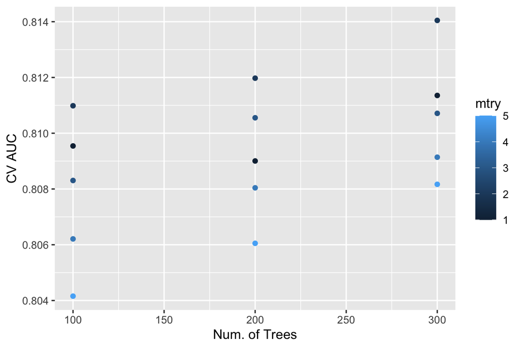

```r
rf_fit %>%
  collect_metrics() %>%
  print(width = Inf) %>%
  filter(.metric == "roc_auc") %>%
  ggplot(mapping = aes(x = trees, y = mean, color = mtry)) +
  geom_point() +
  # geom_line() +
  labs(x = "Num. of Trees", y = "CV AUC")
```

```r
rf_fit %>%
  show_best("roc_auc")
```

```
# A tibble: 5 × 8
   mtry trees .metric .estimator  mean     n std_err .config
  <int> <int> <chr>   <chr>      <dbl> <int>   <dbl> <chr>
1     2   300 roc_auc binary     0.814     5 0.00598 Preprocessor1_Model06
2     2   200 roc_auc binary     0.812     5 0.00623 Preprocessor1_Model05
3     1   300 roc_auc binary     0.811     5 0.00658 Preprocessor1_Model03
4     2   100 roc_auc binary     0.811     5 0.00655 Preprocessor1_Model04
5     3   300 roc_auc binary     0.811     5 0.00632 Preprocessor1_Model09
```

```r
best_rf <- rf_fit %>%
  select_best("roc_auc")
best_rf
```

```
# A tibble: 1 × 3
   mtry trees .config
  <int> <int> <chr>
1     2   300 Preprocessor1_Model06
```

```r
# Final workflow
final_wf_rf <- rf_wf %>%
  finalize_workflow(best_rf)
final_wf_rf
```

```
══ Workflow ════════════════════════════════════════════════════════════════════
Preprocessor: Recipe
Model: rand_forest()

── Preprocessor ────────────────────────────────────────────────────────────────
15 Recipe Steps

• step_impute_mode()
• step_impute_mean()
• step_impute_mean()
• step_impute_mean()
• step_impute_mean()
• step_impute_mean()
• step_impute_mean()
• step_impute_mean()
• step_impute_mean()
• step_impute_mean()
• ...
• and 5 more steps.

── Model ───────────────────────────────────────────────────────────────────────
Random Forest Model Specification (classification)

Main Arguments:
  mtry = 2
  trees = 300

Computational engine: ranger
```

```r
# Fit the whole training set, then predict the test cases
final_fit_rf <-
  final_wf_rf %>%
  last_fit(data_split)
final_fit_rf
```

```
# Resampling results
# Manual resampling
# A tibble: 1 × 6
  splits                id               .metrics .notes   .predict…¹ .workflow
  <list>                <chr>            <list>   <list>   <list>     <list>
1 <split [26532/26533]> train/test split <tibble> <tibble> <tibble>   <workflow>
# … with abbreviated variable name ¹.predictions
```

```r
# Test metrics
final_fit_rf %>%
  collect_metrics()
```

```
# A tibble: 2 × 4
  .metric  .estimator .estimate .config
  <chr>    <chr>          <dbl> <chr>
1 accuracy binary         0.907 Preprocessor1_Model1
2 roc_auc  binary         0.815 Preprocessor1_Model1
```

### 1.2 Logistic Regression Model

```r
logit_recipe <-
  recipe(
    thirty_day_mort ~ .,
    data = ic_training
  ) %>%
  # Imputation for the missing value
  # mode imputation for martial_status
  step_impute_mode(marital_status) %>%
  # mean imputation for potassium
  step_impute_mean(potassium) %>%
  # mean imputation for  sodium
  step_impute_mean(sodium) %>%
  # mean imputation for discharge_location
  step_impute_mean(glucose) %>%
  # mean imputation for creatinine
  step_impute_mean(creatinine) %>%
  # mean imputation for hematocrit
  step_impute_mean(hematocrit) %>%
  # mean imputation for bicarbonate
  step_impute_mean(bicarbonate) %>%
  # mean imputation for n_wb_cell
  step_impute_mean(n_wb_cell) %>%
  # mean imputation for chloride
  step_impute_mean(chloride) %>%
  # mean imputation for body_temp
  step_impute_mean(body_temp) %>%
  # mean imputation sni_blood_pressure
  step_impute_mean(sni_blood_pressure) %>%
  # mean imputation ni_blood_pressure
  step_impute_mean(ni_blood_pressure) %>%
  # mean imputation respiratory_rate
  step_impute_mean(respiratory_rate) %>%
  # mean imputation heart_rate
  step_impute_mean(heart_rate) %>%
  # zero-variance filter
  step_zv(all_numeric_predictors()) %>%
  # create traditional dummy variables
  step_dummy(all_nominal_predictors()) %>%
  # center and scale numeric data
  step_normalize(all_numeric_predictors()) %>%
  # estimate the means and standard deviations
  prep(training = ic_training, retain = TRUE)
rf_recipe
```

```
Recipe

Inputs:

      role #variables
   outcome          1
 predictor         17

Training data contained 26532 data points and 10209 incomplete rows.

Operations:

Mode imputation for marital_status [trained]
Mean imputation for potassium [trained]
Mean imputation for sodium [trained]
Mean imputation for glucose [trained]
Mean imputation for creatinine [trained]
Mean imputation for hematocrit [trained]
Mean imputation for bicarbonate [trained]
Mean imputation for n_wb_cell [trained]
Mean imputation for chloride [trained]
Mean imputation for body_temp [trained]
Mean imputation for sni_blood_pressure [trained]
Mean imputation for ni_blood_pressure [trained]
Mean imputation for respiratory_rate [trained]
Mean imputation for heart_rate [trained]
Zero variance filter removed <none> [trained]
```

```r
logit_mod <-
  logistic_reg(
    penalty = tune(),
    mixture = tune()
  ) %>%
  set_engine("glmnet", standardize = FALSE)
logit_mod
```

```
Logistic Regression Model Specification (classification)

Main Arguments:
  penalty = tune()
  mixture = tune()

Engine-Specific Arguments:
  standardize = FALSE

Computational engine: glmnet
```

```r
logit_wf <- workflow() %>%
  add_recipe(logit_recipe) %>%
  add_model(logit_mod)
logit_wf
```

```
══ Workflow ════════════════════════════════════════════════════════════════════
Preprocessor: Recipe
Model: logistic_reg()

── Preprocessor ────────────────────────────────────────────────────────────────
17 Recipe Steps

• step_impute_mode()
• step_impute_mean()
• step_impute_mean()
• step_impute_mean()
• step_impute_mean()
• step_impute_mean()
• step_impute_mean()
• step_impute_mean()
• step_impute_mean()
• step_impute_mean()
• ...
• and 7 more steps.

── Model ───────────────────────────────────────────────────────────────────────
Logistic Regression Model Specification (classification)

Main Arguments:
  penalty = tune()
  mixture = tune()

Engine-Specific Arguments:
  standardize = FALSE

Computational engine: glmnet
```

```r
param_grid_logit <- grid_regular(
  penalty(range = c(-4, -1)),
  mixture(), #proportion of Lasso Penalty
  levels = c(100, 10)
  )
param_grid_logit
```

```
# A tibble: 1,000 × 2
    penalty mixture
      <dbl>   <dbl>
 1 0.0001         0
 2 0.000107       0
 3 0.000115       0
 4 0.000123       0
 5 0.000132       0
 6 0.000142       0
 7 0.000152       0
 8 0.000163       0
 9 0.000175       0
10 0.000187       0
# … with 990 more rows
```

```r
logit_fit <- logit_wf %>%
  tune_grid(
    resamples = folds,
    grid = param_grid_logit,
    metrics = metric_set(roc_auc, accuracy)
    )
```

```r
logit_fit
```

```
# Tuning results
# 5-fold cross-validation
# A tibble: 5 × 4
  splits               id    .metrics             .notes
  <list>               <chr> <list>               <list>
1 <split [21225/5307]> Fold1 <tibble [2,000 × 6]> <tibble [0 × 3]>
2 <split [21225/5307]> Fold2 <tibble [2,000 × 6]> <tibble [0 × 3]>
3 <split [21226/5306]> Fold3 <tibble [2,000 × 6]> <tibble [0 × 3]>
4 <split [21226/5306]> Fold4 <tibble [2,000 × 6]> <tibble [0 × 3]>
5 <split [21226/5306]> Fold5 <tibble [2,000 × 6]> <tibble [0 × 3]>
```

```
# A tibble: 2,000 × 8
    penalty mixture .metric  .estimator  mean     n std_err
      <dbl>   <dbl> <chr>    <chr>      <dbl> <int>   <dbl>
 1 0.0001         0 accuracy binary     0.900     5 0.00303
 2 0.0001         0 roc_auc  binary     0.755     5 0.00490
 3 0.000107       0 accuracy binary     0.900     5 0.00303
 4 0.000107       0 roc_auc  binary     0.755     5 0.00490
 5 0.000115       0 accuracy binary     0.900     5 0.00303
 6 0.000115       0 roc_auc  binary     0.755     5 0.00490
 7 0.000123       0 accuracy binary     0.900     5 0.00303
 8 0.000123       0 roc_auc  binary     0.755     5 0.00490
 9 0.000132       0 accuracy binary     0.900     5 0.00303
10 0.000132       0 roc_auc  binary     0.755     5 0.00490
   .config
   <chr>
 1 Preprocessor1_Model0001
 2 Preprocessor1_Model0001
 3 Preprocessor1_Model0002
 4 Preprocessor1_Model0002
 5 Preprocessor1_Model0003
 6 Preprocessor1_Model0003
 7 Preprocessor1_Model0004
 8 Preprocessor1_Model0004
 9 Preprocessor1_Model0005
10 Preprocessor1_Model0005
# … with 1,990 more rows
```

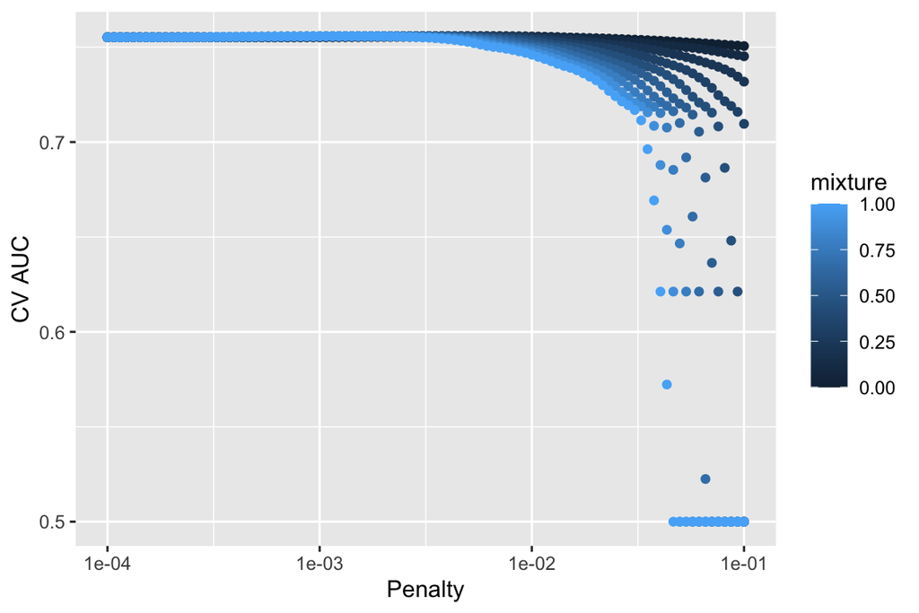

```r
logit_fit %>%
  collect_metrics() %>%
  print(width = Inf) %>%
  filter(.metric == "roc_auc") %>%
  ggplot(mapping = aes(x = penalty, y = mean, color = mixture)) +
  geom_point() +
  labs(x = "Penalty", y = "CV AUC") +
  scale_x_log10()
```

```r
logit_fit %>%
  show_best("roc_auc")
```

```
# A tibble: 5 × 8
  penalty mixture .metric .estimator  mean     n std_err .config
    <dbl>   <dbl> <chr>   <chr>      <dbl> <int>   <dbl> <chr>
1 0.00404   0.222 roc_auc binary     0.756     5 0.00503 Preprocessor1_Model0254
2 0.00433   0.222 roc_auc binary     0.756     5 0.00504 Preprocessor1_Model0255
3 0.00305   0.333 roc_auc binary     0.756     5 0.00506 Preprocessor1_Model0350
4 0.00376   0.222 roc_auc binary     0.756     5 0.00502 Preprocessor1_Model0253
5 0.00285   0.333 roc_auc binary     0.756     5 0.00504 Preprocessor1_Model0349
```

```r
best_logit <- logit_fit %>%
  select_best("roc_auc")
best_logit
```

```
# A tibble: 1 × 3
  penalty mixture .config
    <dbl>   <dbl> <chr>
1 0.00404   0.222 Preprocessor1_Model0254
```

```r
# Final workflow
final_wf_logit <- logit_wf %>%
  finalize_workflow(best_logit)
final_wf_logit
```

```
══ Workflow ════════════════════════════════════════════════════════════════════
Preprocessor: Recipe
Model: logistic_reg()

── Preprocessor ────────────────────────────────────────────────────────────────
17 Recipe Steps

• step_impute_mode()
• step_impute_mean()
• step_impute_mean()
• step_impute_mean()
• step_impute_mean()
• step_impute_mean()
• step_impute_mean()
• step_impute_mean()
• step_impute_mean()
• step_impute_mean()
• ...
• and 7 more steps.

── Model ───────────────────────────────────────────────────────────────────────
Logistic Regression Model Specification (classification)

Main Arguments:
  penalty = 0.00403701725859656
  mixture = 0.222222222222222

Engine-Specific Arguments:
  standardize = FALSE

Computational engine: glmnet
```

```r
# Fit the whole training set, then predict the test cases
final_fit_logit <-
  final_wf_logit %>%
  last_fit(data_split)
final_fit_logit
```

```
# Resampling results
# Manual resampling
# A tibble: 1 × 6
  splits                id               .metrics .notes   .predict…¹ .workflow
  <list>                <chr>            <list>   <list>   <list>     <list>
1 <split [26532/26533]> train/test split <tibble> <tibble> <tibble>   <workflow>
# … with abbreviated variable name ¹.predictions
```

```r
# Test metrics for logit regression
final_fit_logit %>%
  collect_metrics()
```

```
# A tibble: 2 × 4
  .metric  .estimator .estimate .config
  <chr>    <chr>          <dbl> <chr>
1 accuracy binary         0.905 Preprocessor1_Model1
2 roc_auc  binary         0.761 Preprocessor1_Model1
```

### 1.3 XGBoost Model

```r
gb_recipe <- logit_recipe
gb_mod <-
  boost_tree(
    mode = "classification",
    trees = 1000,
    tree_depth = tune(),
    learn_rate = tune()
  ) %>%
  set_engine("xgboost")
gb_mod
```

```
Boosted Tree Model Specification (classification)

Main Arguments:
  trees = 1000
  tree_depth = tune()
  learn_rate = tune()

Computational engine: xgboost
```

```r
gb_wf <- workflow() %>%
  add_recipe(gb_recipe) %>%
  add_model(gb_mod)
gb_wf
```

```
══ Workflow ════════════════════════════════════════════════════════════════════
Preprocessor: Recipe
Model: boost_tree()

── Preprocessor ────────────────────────────────────────────────────────────────
17 Recipe Steps

• step_impute_mode()
• step_impute_mean()
• step_impute_mean()
• step_impute_mean()
• step_impute_mean()
• step_impute_mean()
• step_impute_mean()
• step_impute_mean()
• step_impute_mean()
• step_impute_mean()
• ...
• and 7 more steps.

── Model ───────────────────────────────────────────────────────────────────────
Boosted Tree Model Specification (classification)

Main Arguments:
  trees = 1000
  tree_depth = tune()
  learn_rate = tune()

Computational engine: xgboost
```

```r
param_grid_gb <- grid_regular(
  tree_depth(range = c(1L, 3L)),
  learn_rate(range = c(-5, 2), trans = log10_trans()),
  levels = c(3, 10)
  )
param_grid_gb
```

```
# A tibble: 30 × 2
   tree_depth learn_rate
        <int>      <dbl>
 1          1  0.00001
 2          2  0.00001
 3          3  0.00001
 4          1  0.0000599
 5          2  0.0000599
 6          3  0.0000599
 7          1  0.000359
 8          2  0.000359
 9          3  0.000359
10          1  0.00215
# … with 20 more rows
```

```r
gb_fit <- gb_wf %>%
  tune_grid(
    resamples = folds,
    grid = param_grid_gb,
    metrics = metric_set(roc_auc, accuracy)
    )
gb_fit
```

```
# Tuning results
# 5-fold cross-validation
# A tibble: 5 × 4
  splits               id    .metrics          .notes
  <list>               <chr> <list>            <list>
1 <split [21225/5307]> Fold1 <tibble [60 × 6]> <tibble [0 × 3]>
2 <split [21225/5307]> Fold2 <tibble [60 × 6]> <tibble [0 × 3]>
3 <split [21226/5306]> Fold3 <tibble [60 × 6]> <tibble [0 × 3]>
4 <split [21226/5306]> Fold4 <tibble [60 × 6]> <tibble [0 × 3]>
5 <split [21226/5306]> Fold5 <tibble [60 × 6]> <tibble [0 × 3]>
```

```
# A tibble: 60 × 8
   tree_depth learn_rate .metric  .estimator  mean     n std_err
        <int>      <dbl> <chr>    <chr>      <dbl> <int>   <dbl>
 1          1  0.00001   accuracy binary     0.899     5 0.00330
 2          1  0.00001   roc_auc  binary     0.606     5 0.0155
 3          2  0.00001   accuracy binary     0.899     5 0.00330
 4          2  0.00001   roc_auc  binary     0.660     5 0.0109
 5          3  0.00001   accuracy binary     0.902     5 0.00314
 6          3  0.00001   roc_auc  binary     0.685     5 0.00749
 7          1  0.0000599 accuracy binary     0.899     5 0.00330
 8          1  0.0000599 roc_auc  binary     0.612     5 0.0121
 9          2  0.0000599 accuracy binary     0.899     5 0.00330
10          2  0.0000599 roc_auc  binary     0.683     5 0.00886
   .config
   <chr>
 1 Preprocessor1_Model01
 2 Preprocessor1_Model01
 3 Preprocessor1_Model02
 4 Preprocessor1_Model02
 5 Preprocessor1_Model03
 6 Preprocessor1_Model03
 7 Preprocessor1_Model04
 8 Preprocessor1_Model04
 9 Preprocessor1_Model05
10 Preprocessor1_Model05
# … with 50 more rows
```

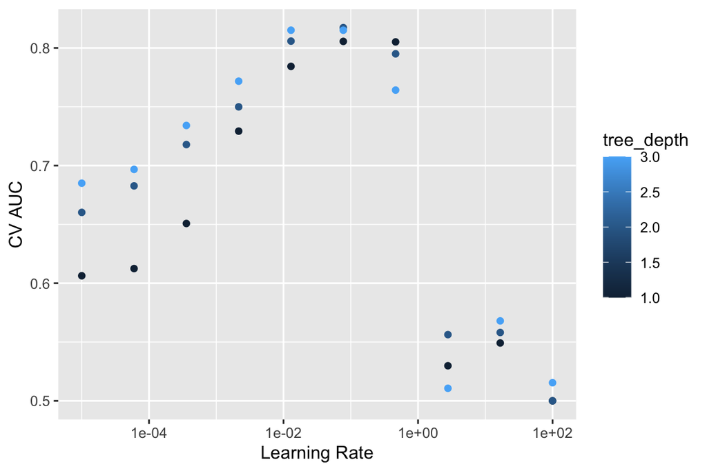

```r
gb_fit %>%
  collect_metrics() %>%
  print(width = Inf) %>%
  filter(.metric == "roc_auc") %>%
  ggplot(mapping = aes(x = learn_rate, y = mean, color = tree_depth)) +
  geom_point() +
  labs(x = "Learning Rate", y = "CV AUC") +
  scale_x_log10()
```

```r
gb_fit %>%
  show_best("roc_auc")
```

```
# A tibble: 5 × 8
  tree_depth learn_rate .metric .estimator  mean     n std_err .config
       <int>      <dbl> <chr>   <chr>      <dbl> <int>   <dbl> <chr>
1          2     0.0774 roc_auc binary     0.817     5 0.00490 Preprocessor1_Mo…
2          3     0.0129 roc_auc binary     0.815     5 0.00434 Preprocessor1_Mo…
3          3     0.0774 roc_auc binary     0.815     5 0.00449 Preprocessor1_Mo…
4          2     0.0129 roc_auc binary     0.806     5 0.00401 Preprocessor1_Mo…
5          1     0.0774 roc_auc binary     0.806     5 0.00487 Preprocessor1_Mo…
```

```r
best_gb <- gb_fit %>%
  select_best("roc_auc")
best_gb
```

```
# A tibble: 1 × 3
  tree_depth learn_rate .config
       <int>      <dbl> <chr>
1          2     0.0774 Preprocessor1_Model17
```

```r
# Final workflow
final_wf_gb <- gb_wf %>%
  finalize_workflow(best_gb)
final_wf_gb
```

```
══ Workflow ════════════════════════════════════════════════════════════════════
Preprocessor: Recipe
Model: boost_tree()

── Preprocessor ────────────────────────────────────────────────────────────────
17 Recipe Steps

• step_impute_mode()
• step_impute_mean()
• step_impute_mean()
• step_impute_mean()
• step_impute_mean()
• step_impute_mean()
• step_impute_mean()
• step_impute_mean()
• step_impute_mean()
• step_impute_mean()
• ...
• and 7 more steps.

── Model ───────────────────────────────────────────────────────────────────────
Boosted Tree Model Specification (classification)

Main Arguments:
  trees = 1000
  tree_depth = 2
  learn_rate = 0.0774263682681127

Computational engine: xgboost
```

```r
# Fit the whole training set, then predict the test cases
final_fit_gb <-
  final_wf_gb %>%
  last_fit(data_split)
final_fit_gb
```

```
# Resampling results
# Manual resampling
# A tibble: 1 × 6
  splits                id               .metrics .notes   .predict…¹ .workflow
  <list>                <chr>            <list>   <list>   <list>     <list>
1 <split [26532/26533]> train/test split <tibble> <tibble> <tibble>   <workflow>
# … with abbreviated variable name ¹.predictions
```

```r
# Test metrics
final_fit_gb %>%
  collect_metrics()
```

```
# A tibble: 2 × 4
  .metric  .estimator .estimate .config
  <chr>    <chr>          <dbl> <chr>
1 accuracy binary         0.912 Preprocessor1_Model1
2 roc_auc  binary         0.822 Preprocessor1_Model1
```

3. Compare model classification performance on the test set. Report both the area under ROC curve and accuracy for each model.

| Model | AUC | Accuracy |
| --- | --- | --- |
| Random Forest | 0.815 | 0.907 |
| Logistic Regression | 0.761 | 0.905 |
| XGBoost | 0.822 | 0.912 |

XGBoost has the best performance on AUC score and accuracy.